# Exercise 10

Author

Gianfranco Botta (GianfrancoBotta)

Published

November 28, 2023

## Import libraries

```r
suppressPackageStartupMessages(library(scuttle))
suppressPackageStartupMessages(library(scran))
suppressPackageStartupMessages(library(scater))
suppressPackageStartupMessages(library(BiocParallel))
suppressPackageStartupMessages(library(ggplot2))
suppressPackageStartupMessages(library(HDF5Array))
suppressPackageStartupMessages(library(hdf5r))
suppressPackageStartupMessages(library(pheatmap))
BPPARAM = BiocParallel::MulticoreParam(workers=2)
BPPARAM = BiocParallel::SerialParam()
library(mclust)
```

## Question 1

*Load the data*

```r
sce = readRDS("C:/Users/gianf/OneDrive/Documenti/DOCUMENTS_ETH/1 YEAR/1 SEMESTER/SAHTGTD/EXERCISES/pbmc-sce.RDS")
sce
```

```
class: SingleCellExperiment
dim: 36601 10194
metadata(1): Samples
assays(1): counts
rownames(36601): ENSG00000243485 ENSG00000237613 ... ENSG00000278817
  ENSG00000277196
rowData names(3): ID Symbol Type
colnames: NULL
colData names(3): Sample Barcode cellType
reducedDimNames(0):
mainExpName: NULL
altExpNames(0):
```

Optionally subsample 2000 cells to reduce runtime

```r
set.seed(38)
sce = sce[ , sample(1:ncol(sce), size = 2000, replace = FALSE)]
```

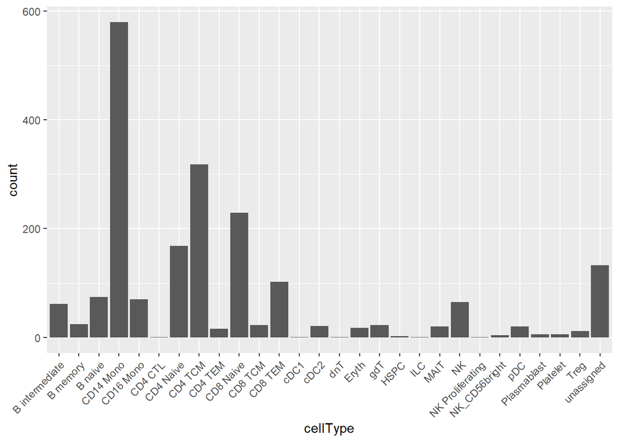

```r
cd = as.data.frame(colData(sce))
ggplot(cd, aes(x=cellType)) + geom_bar() +
   scale_fill_manual() + theme(axis.text.x = element_text(angle = 45, vjust = 1, hjust=1))
```

## Question 2

*Compute and visualize quality scores:* *- number of detected genes* *- number of assigned reads* *- percentage of mitochondrial reads*

```r
isMito <- grepl("^mt-", rowData(sce)$Symbol, ignore.case=TRUE)

sce <- addPerCellQC(sce, subsets=list(Mito=isMito), percent_top=100,
                    detection_limit=0, BPPARAM=BPPARAM)
```

Number of detected genes:

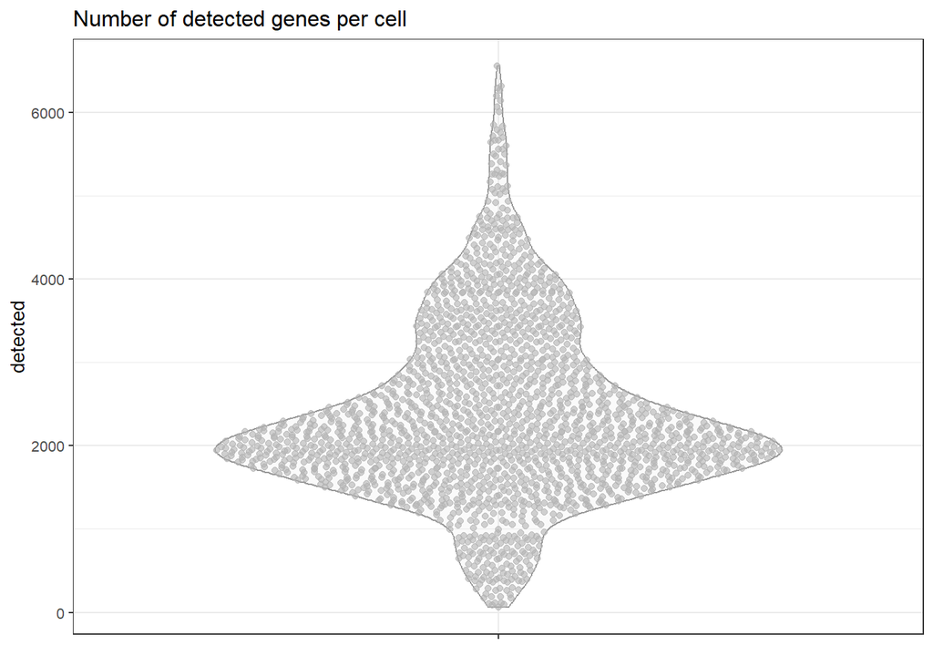

```r
plotColData(sce, y = "detected") +
  ggtitle("Number of detected genes per cell")
```

Number of assigned reads:

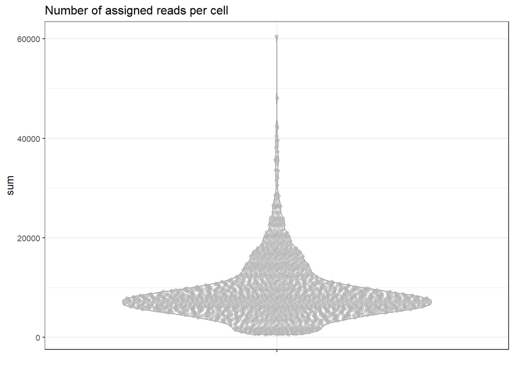

```r
plotColData(sce, y = "sum") +
  ggtitle("Number of assigned reads per cell")
```

Percentage of mitochondrial reads:

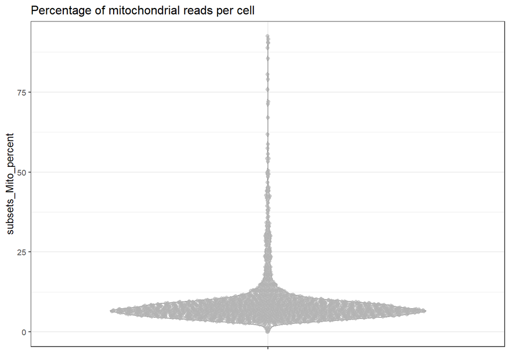

```r
plotColData(sce, y = "subsets_Mito_percent") +
  ggtitle("Percentage of mitochondrial reads per cell")
```

Percentage of expression in the top 100 genes:

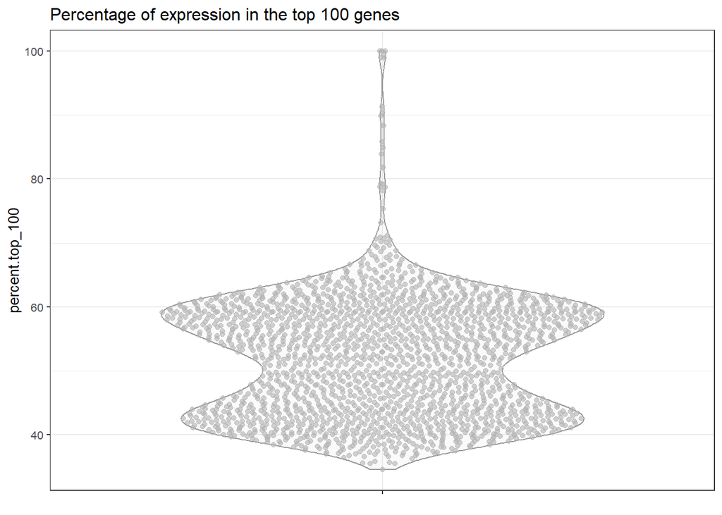

```r
plotColData(sce, y = "percent.top_100") +
  ggtitle("Percentage of expression in the top 100 genes")
```

*Filter by quality scores. The function isOutlier defines outliers based on the difference to the median scores. Refer to the manual. Consider also setting manual thresholds.*

```r
qc.lib <- isOutlier(sce$sum, log=TRUE, type="lower")
qc.nexprs <- isOutlier(sce$detected, log=TRUE, type="lower")
qc.mito <- isOutlier(sce$subsets_Mito_percent, type="higher")
qc.top <- isOutlier(sce$percent.top_100, type="higher")

discard <- qc.lib | qc.nexprs | qc.mito | qc.top

DataFrame(LibSize=sum(qc.lib), NExprs=sum(qc.nexprs),
          MitoProp=sum(qc.mito),
          TopProp=sum(qc.top), Total=sum(discard))
```

```
DataFrame with 1 row and 5 columns
    LibSize    NExprs  MitoProp   TopProp     Total
  <integer> <integer> <integer> <integer> <integer>
1        93        68       149        11       165
```

```r
sce$discard = discard

sceFilt = sce[ , !sce$discard]
minCellsExpressed = 5
isExpressed <- Matrix::rowSums(counts(sceFilt) >= 1) >= minCellsExpressed
sceFilt = sceFilt[isExpressed, ]
```

Now we can visualize all the filtered data using plotColData:

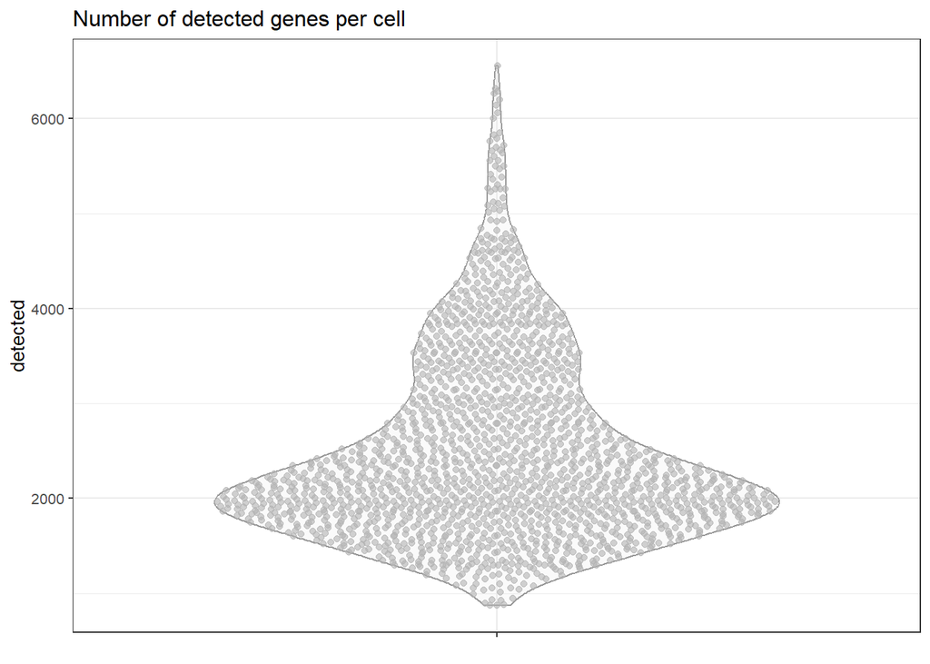

```r
plotColData(sceFilt, y = "detected") +
  ggtitle("Number of detected genes per cell")
```

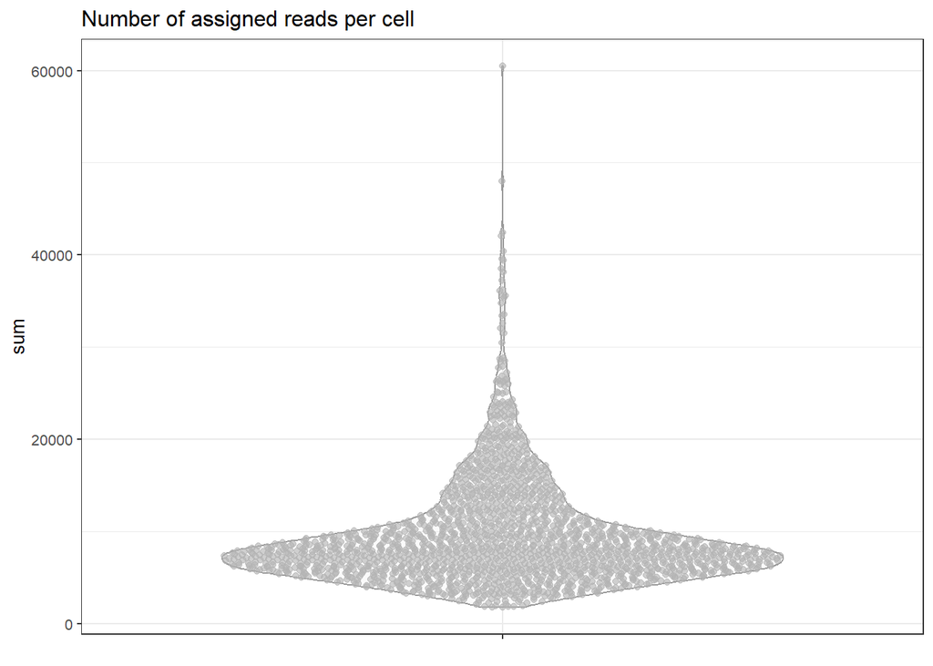

```r
plotColData(sceFilt, y = "sum") +
  ggtitle("Number of assigned reads per cell")
```

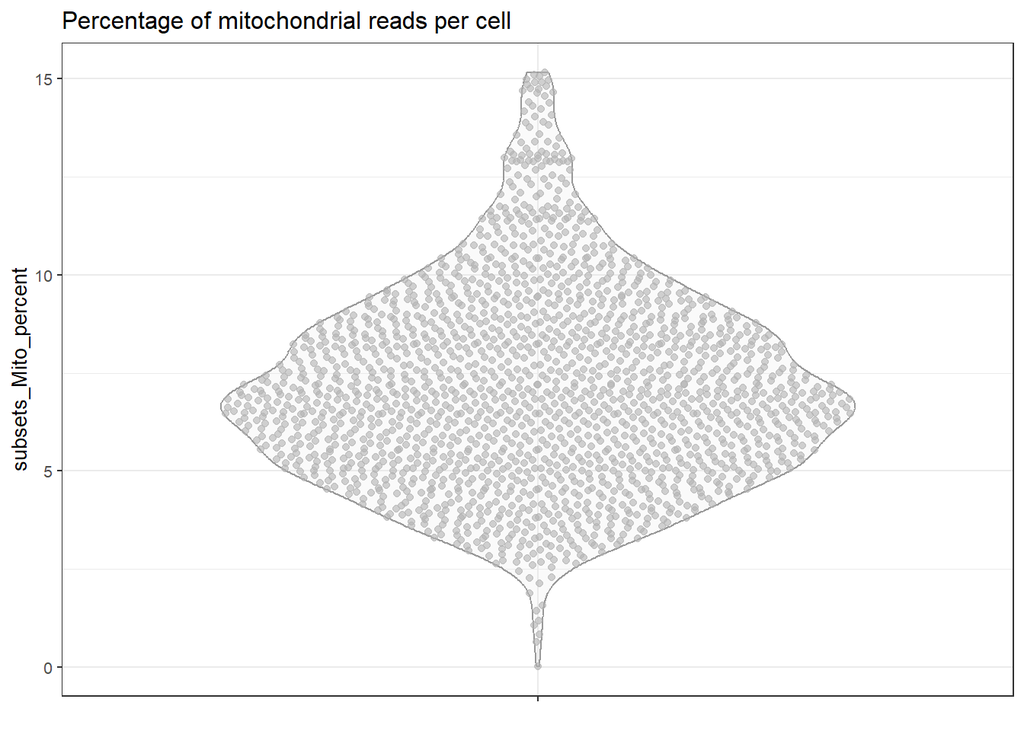

```r
plotColData(sceFilt, y = "subsets_Mito_percent") +
  ggtitle("Percentage of mitochondrial reads per cell")
```

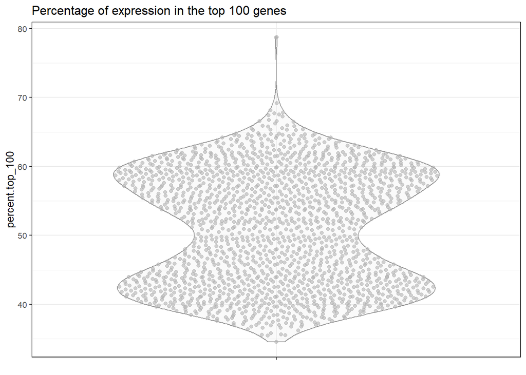

```r
plotColData(sceFilt, y = "percent.top_100") +
  ggtitle("Percentage of expression in the top 100 genes")
```

We see our filtering seems to have succeded well. However, we can try to filter with some stricter conditions. Therefore, now we treat cells as outliers if the minimum number of MADs away from median is 1 (nmads = 1), and each gene has to be expressed in at least 20 cells to be considered (with a count > 1).

```r
qc.lib_2 <- isOutlier(sce$sum, log=TRUE, type="lower", nmads = 1)
qc.nexprs_2 <- isOutlier(sce$detected, log=TRUE, type="lower", nmads = 1)
qc.mito_2 <- isOutlier(sce$subsets_Mito_percent, type="higher", nmads = 1)
qc.top_2 <- isOutlier(sce$percent.top_100, type="higher", nmads = 1)

discard2 <- qc.lib_2 | qc.nexprs_2 | qc.mito_2 | qc.top_2

DataFrame(LibSize=sum(qc.lib_2), NExprs=sum(qc.nexprs_2),
          MitoProp=sum(qc.mito_2),
          TopProp=sum(qc.top_2), Total=sum(discard2))
```

```
DataFrame with 1 row and 5 columns
    LibSize    NExprs  MitoProp   TopProp     Total
  <integer> <integer> <integer> <integer> <integer>
1       362       279       403       132       636
```

```r
sce$discard2 = discard2

sceFilt2 = sce[ , !sce$discard2]
minCellsExpressed2 = 20
isExpressed2 <- Matrix::rowSums(counts(sceFilt2) >= 1) >= minCellsExpressed2
sceFilt2 = sceFilt2[isExpressed2, ]
```

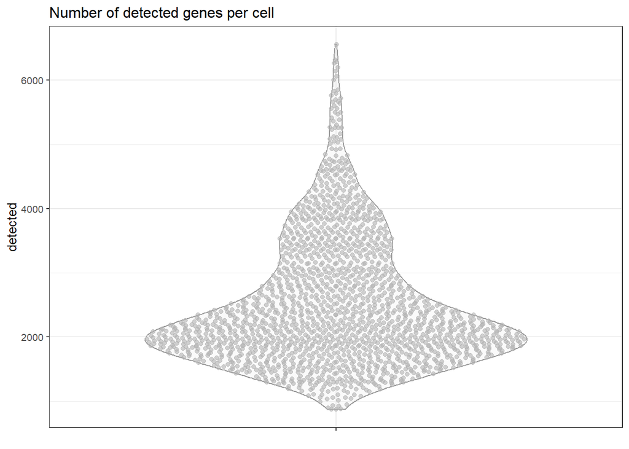

```r
plotColData(sceFilt, y = "detected") +
  ggtitle("Number of detected genes per cell")
```

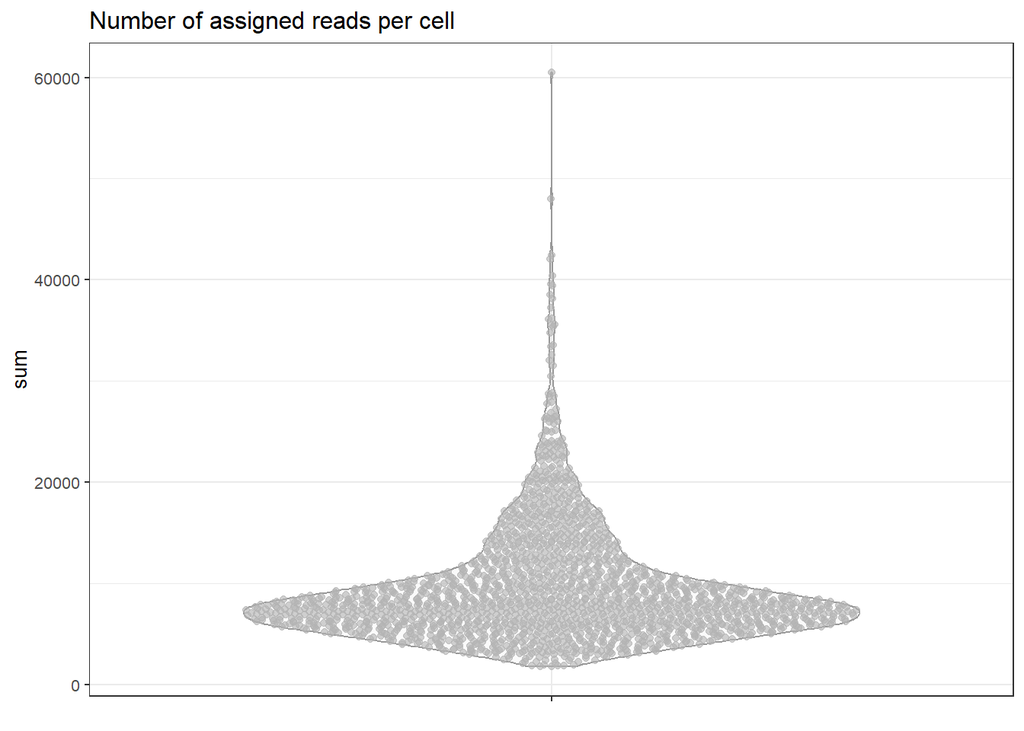

```r
plotColData(sceFilt, y = "sum") +
  ggtitle("Number of assigned reads per cell")
```

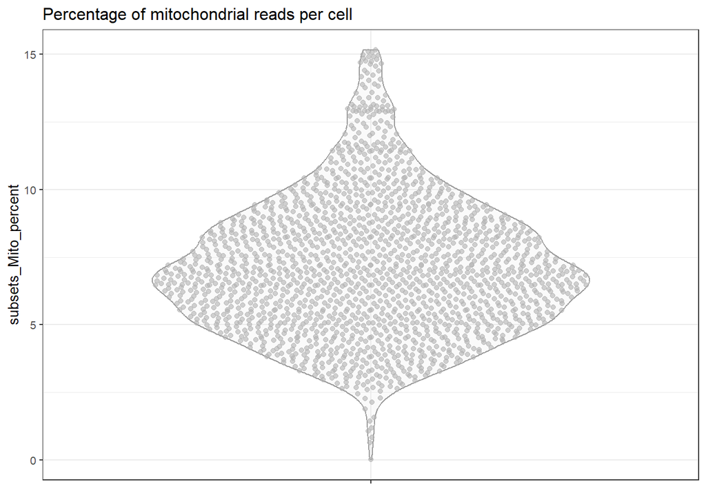

```r
plotColData(sceFilt, y = "subsets_Mito_percent") +
  ggtitle("Percentage of mitochondrial reads per cell")
```

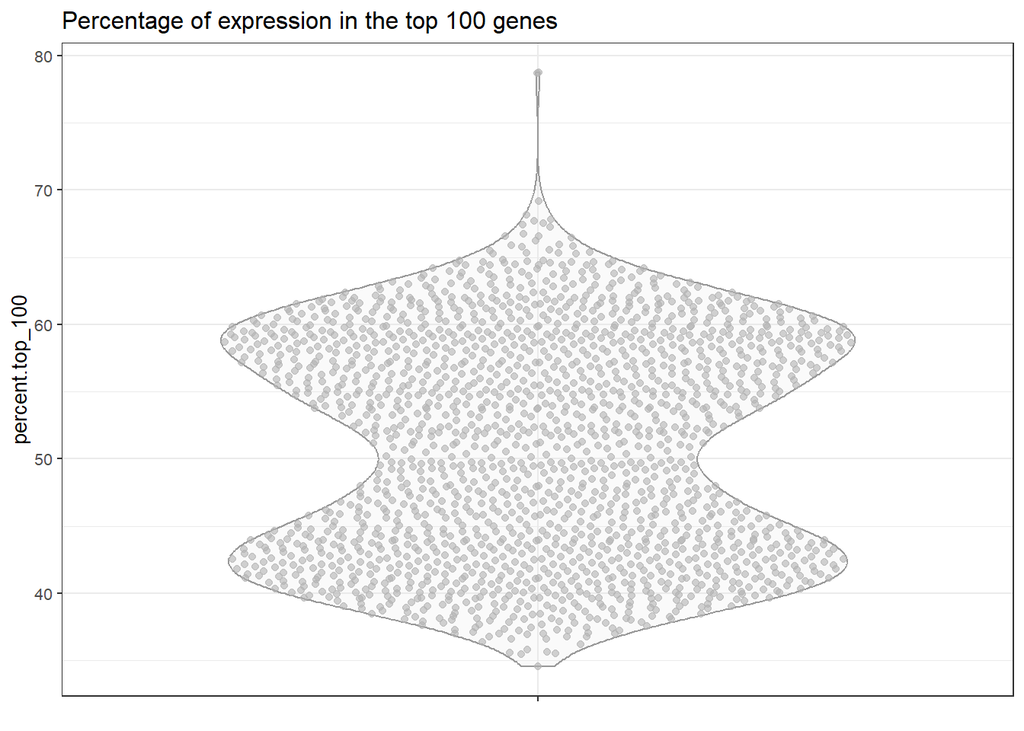

```r
plotColData(sceFilt, y = "percent.top_100") +
  ggtitle("Percentage of expression in the top 100 genes")
```

## Question 3

```r
sceFilt = logNormCounts(sceFilt)
```

```r
set.seed(38)
dec <- modelGeneVarByPoisson(sceFilt, BPPARAM=BPPARAM)
topGenes <- getTopHVGs(dec, n = 2000)
sceFilt <- scater::runPCA(sceFilt, subset_row=topGenes, BPPARAM=BPPARAM)
sceFilt <- scater::runUMAP(sceFilt, dimred="PCA", BPPARAM=BPPARAM)
```

```r
set.seed(100)

clust.kmeans <- kmeans(reducedDim(sceFilt, "PCA"), centers=10)
table(clust.kmeans$cluster)
```

```
  1   2   3   4   5   6   7   8   9  10
241  75 343 209  67 250 172 138 253  87
```

To determine the number of clusters for the k-means, we use the classical elbow method:

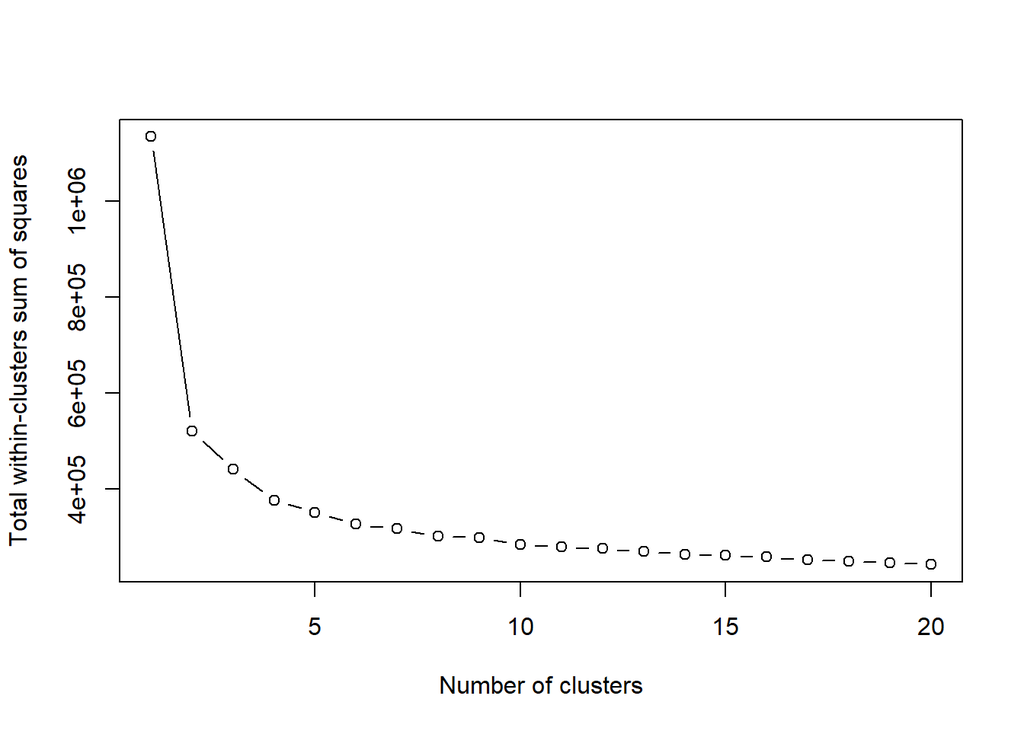

```r
set.seed(100)

wss <- sapply(1:20, function(k){
    kmeans(reducedDim(sceFilt, "PCA"), centers=k, nstart=20)$tot.withinss
})
plot(1:20, wss, type="b", xlab="Number of clusters", ylab="Total within-clusters sum of squares")
```

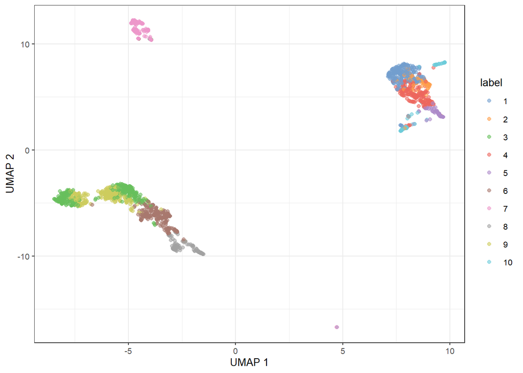

```r
sceFilt_km12 = sceFilt
sceFilt_km16 = sceFilt
sceFilt_km26 = sceFilt

# kmenas-original parameters
colLabels(sceFilt) <- factor(clust.kmeans$cluster)
plotReducedDim(sceFilt, "UMAP", colour_by="label")
```

```r
clust.kmeans.12 <- kmeans(reducedDim(sceFilt, "PCA"), centers=12)
table(clust.kmeans.12$cluster)
```

```
  1   2   3   4   5   6   7   8   9  10  11  12
144  16 154 237  51 280 246  88 155 222 102 140
```

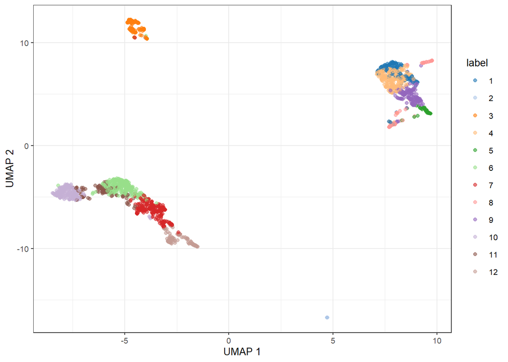

```r
colLabels(sceFilt_km12) <- factor(clust.kmeans.12$cluster)
plotReducedDim(sceFilt_km12, "UMAP", colour_by="label")
```

```r
clust.kmeans.16 <- kmeans(reducedDim(sceFilt, "PCA"), centers=16)
table(clust.kmeans.16$cluster)
```

```
  1   2   3   4   5   6   7   8   9  10  11  12  13  14  15  16
132 581  81  62  85  69   8 113 130  97  21  50 213 102  75  16
```

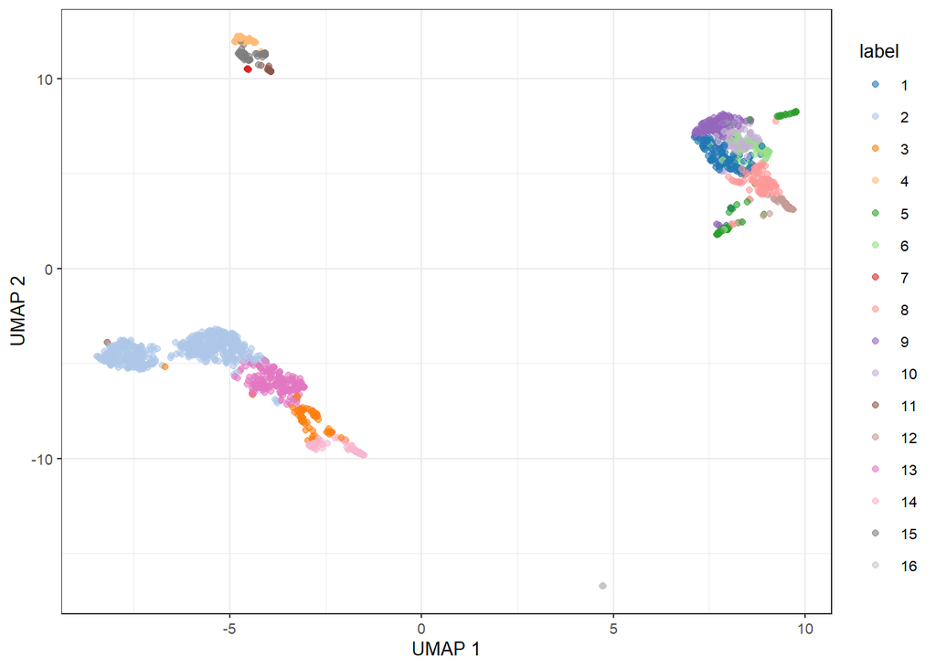

```r
colLabels(sceFilt_km16) <- factor(clust.kmeans.16$cluster)
plotReducedDim(sceFilt_km16, "UMAP", colour_by="label")
```

```r
clust.kmeans.26 <- kmeans(reducedDim(sceFilt, "PCA"), centers=26)
table(clust.kmeans.26$cluster)
```

```
  1   2   3   4   5   6   7   8   9  10  11  12  13  14  15  16  17  18  19  20
 66 140  19 184  66  63 139  88  51  43  64 100  75 113   5  45  95   8  27  74
 21  22  23  24  25  26
 50 109  87  58  16  50
```

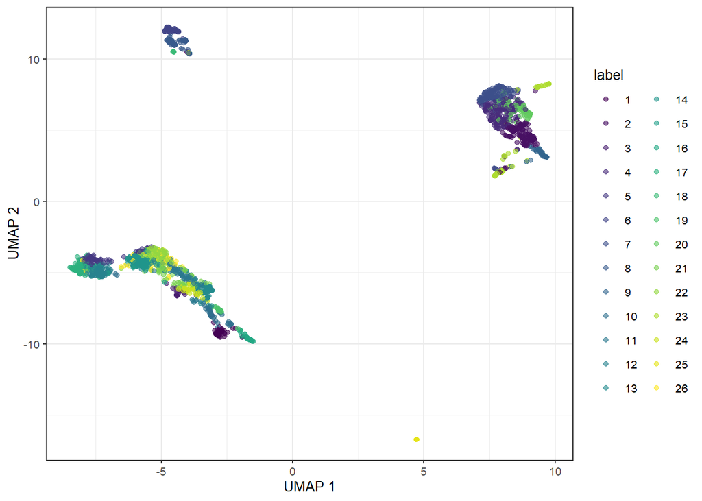

```r
colLabels(sceFilt_km26) <- factor(clust.kmeans.26$cluster)
plotReducedDim(sceFilt_km26, "UMAP", colour_by="label")
```

We can finally color the clusters based on the cell type.

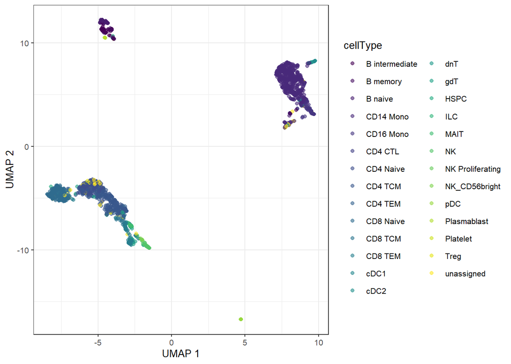

```r
plotReducedDim(sceFilt, "UMAP", colour_by="cellType")
```

We may also perform other graph based clustering algorithms, such as: walktrap, louvain, leiden.

Walktrap:

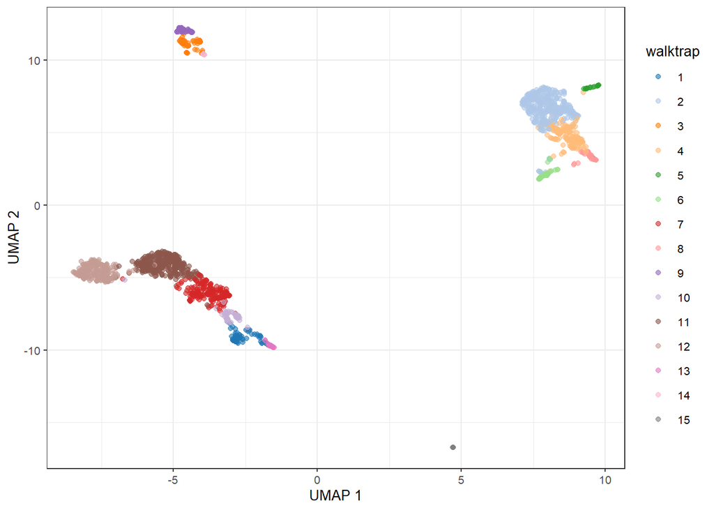

```r
graph_k10 <- scran::buildSNNGraph(sceFilt, k = 10, use.dimred = "PCA", type = "rank")
clust_walktrap_k10 <- igraph::cluster_walktrap(graph_k10)$membership
sceFilt$walktrap <- factor(clust_walktrap_k10)
plotReducedDim(sceFilt, "UMAP", colour_by= "walktrap")
```

Louvain:

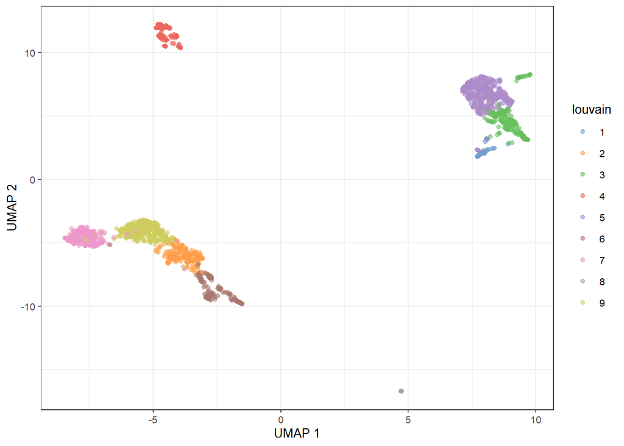

```r
clust_louvain_k10 <- igraph::cluster_louvain(graph_k10)$membership
sceFilt$louvain <- factor(clust_louvain_k10)
plotReducedDim(sceFilt, "UMAP", colour_by="louvain")
```

Leiden:

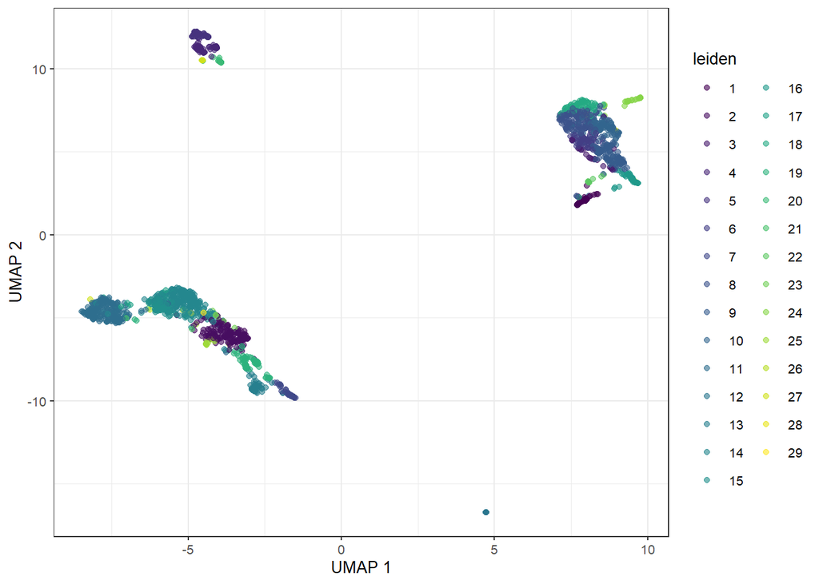

```r
clust_leiden_k10 <- igraph::cluster_leiden(graph_k10)$membership
sceFilt$leiden <- factor(clust_leiden_k10)
plotReducedDim(sceFilt, "UMAP", colour_by="leiden")
```

## Question 4

*Compute agreement of clusters with cell types.*

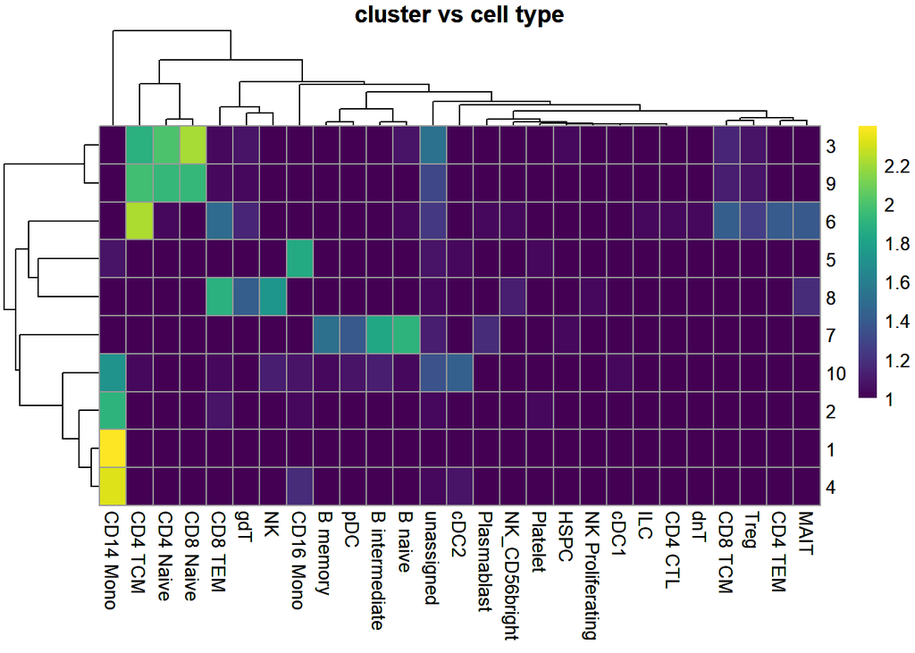

```r
tab <- table(sceFilt$label, sceFilt$cellType)
phm <- pheatmap(log10(tab+10), main="cluster vs cell type",
    color=viridis::viridis(100), silent=FALSE)
phm
```

```r
mean(sce$discard[sce$cellType == "unassigned"])
```

```
[1] 0.5413534
```

```r
mean(!sce$discard[sce$cellType != "unassigned"])
```

```
[1] 0.9501875
```

```r
mean(sce$discard2[sce$cellType == "unassigned"])
```

```
[1] 0.6691729
```

```r
mean(!sce$discard2[sce$cellType != "unassigned"])
```

```
[1] 0.7070166
```

Now only 70 % of assigned cells are kept in the data. However 67 % of the unassigned cells are discarded which is an improvement to the less strict filtering. Of course, a trade-off has to be found. In the following tasks, we will use the less stricter filtering.

1. Agreement of clustering and cell type

```r
mclust::adjustedRandIndex(sceFilt$label,sceFilt$cellType)
```

```
[1] 0.3541787
```

2. Runtime in seconds

```r
paste(signif((proc.time() - startTime)[ "elapsed"], digits=4), "s")
```

```
[1] "37.1 s"
```

We can now evaluate the other cluster sizes for k-means we took into consideration before:

1. 12 clusters:

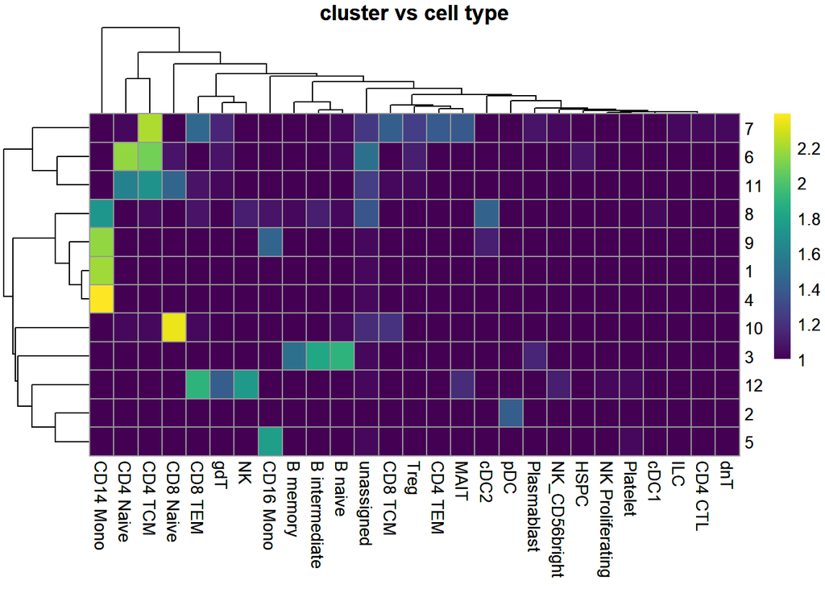

```r
tab <- table(sceFilt_km12$label, sceFilt$cellType)
phm <- pheatmap(log10(tab+10), main="cluster vs cell type",
    color=viridis::viridis(100), silent=FALSE)
phm
```

```r
mclust::adjustedRandIndex(sceFilt_km12$label,sceFilt$cellType)
```

```
[1] 0.4264324
```

2. 16 clusters:

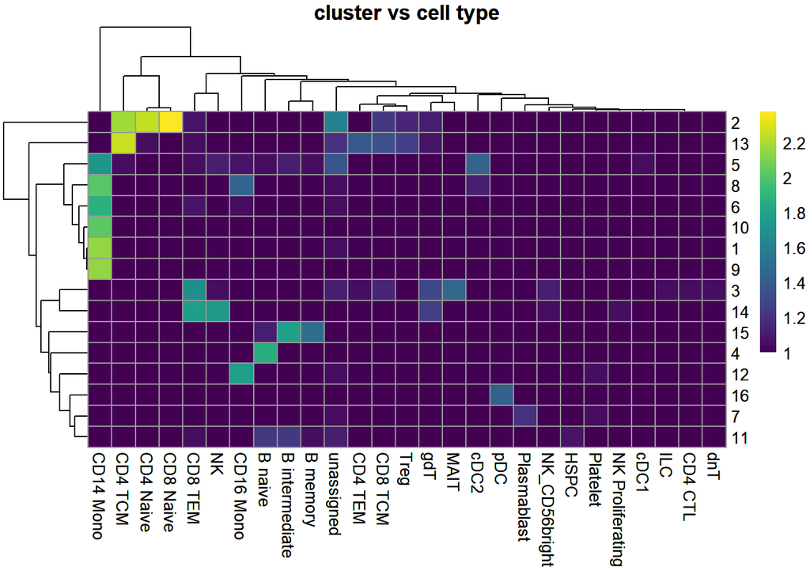

```r
tab <- table(sceFilt_km16$label, sceFilt$cellType)
phm <- pheatmap(log10(tab+10), main="cluster vs cell type",
    color=viridis::viridis(100), silent=FALSE)
phm
```

```r
mclust::adjustedRandIndex(sceFilt_km16$label,sceFilt$cellType)
```

```
[1] 0.302595
```

3. 26 clusters:

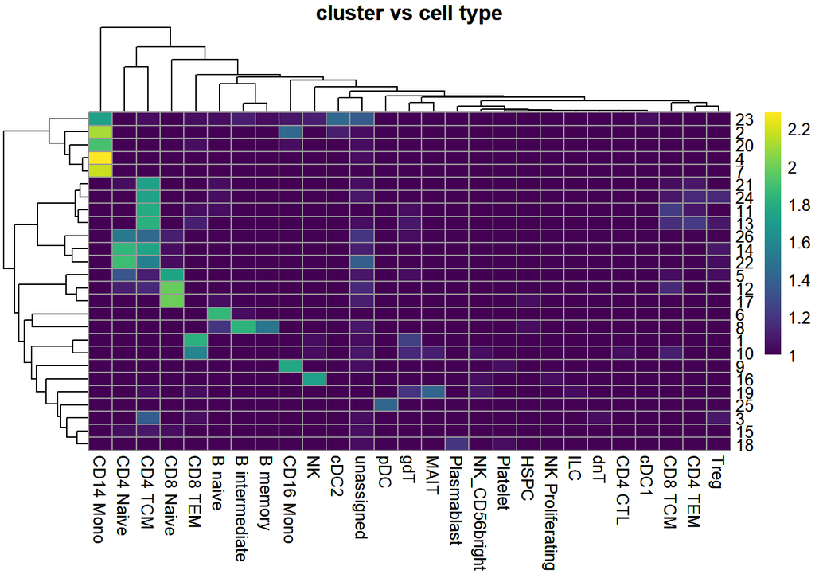

```r
tab <- table(sceFilt_km26$label, sceFilt$cellType)
phm <- pheatmap(log10(tab+10), main="cluster vs cell type",
    color=viridis::viridis(100), silent=FALSE)
phm
```

```r
mclust::adjustedRandIndex(sceFilt_km26$label,sceFilt$cellType)
```

```
[1] 0.3227859
```

Furthermore, as we did in question 3, we can evaluate also the other clustering algorithms:

1. Walktrap:

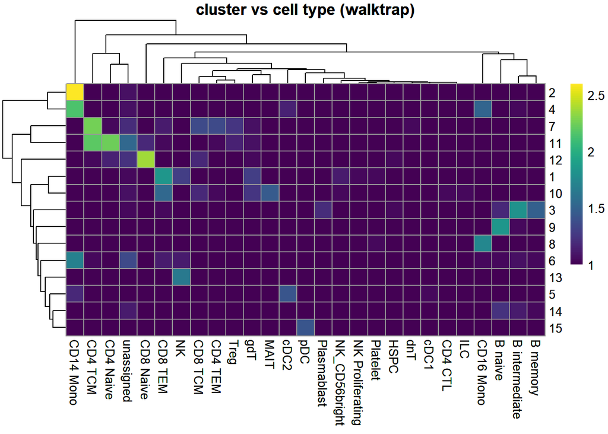

```r
tab <- table(sceFilt$walktrap, sceFilt$cellType)
phm <- pheatmap(log10(tab+10), main="cluster vs cell type (walktrap)",
    color=viridis::viridis(100), silent=FALSE)
phm
```

```r
mclust::adjustedRandIndex(sceFilt$walktrap,sceFilt$cellType)
```

```
[1] 0.5930787
```

2. Louvain:

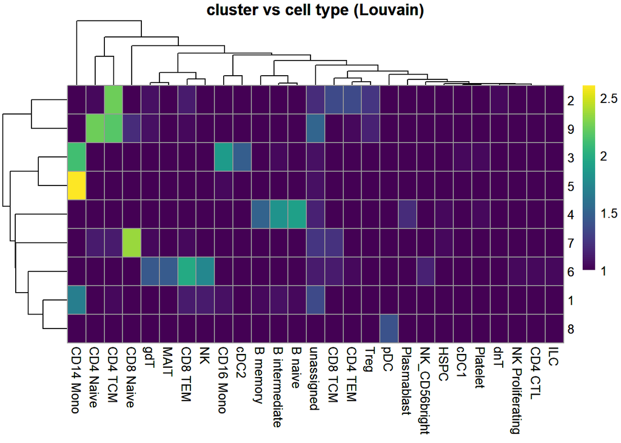

```r
tab <- table(sceFilt$louvain, sceFilt$cellType)
phm <- pheatmap(log10(tab+10), main="cluster vs cell type (Louvain)",
    color=viridis::viridis(100), silent=FALSE)
phm
```

```r
mclust::adjustedRandIndex(sceFilt$louvain,sceFilt$cellType)
```

```
[1] 0.5714955
```

3. Leiden

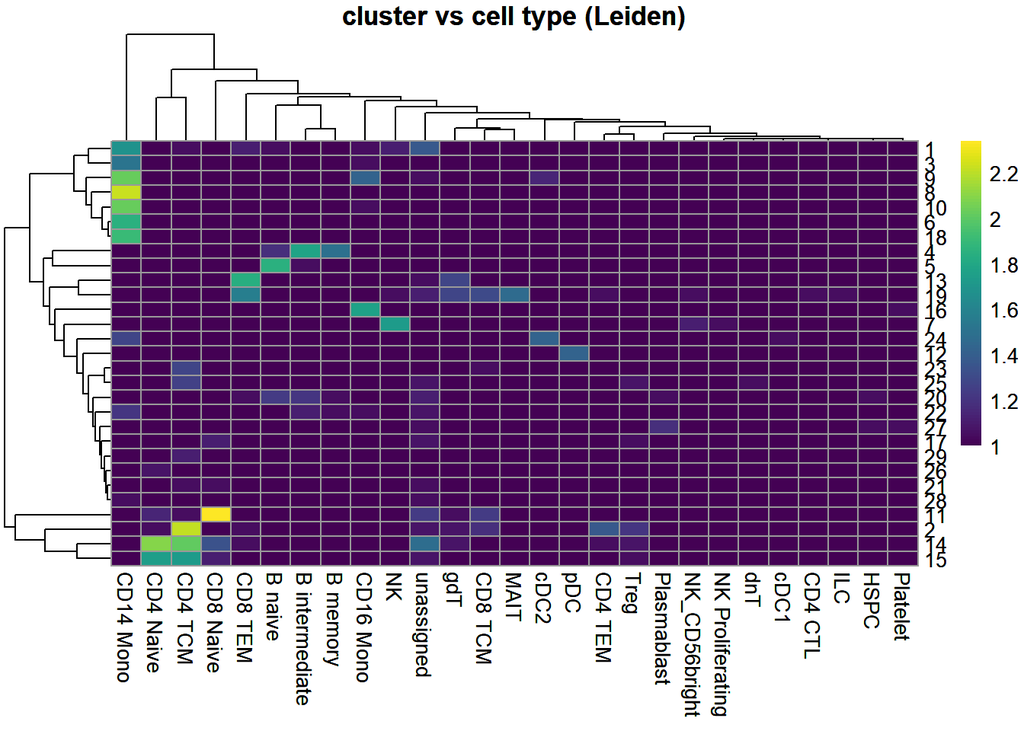

```r
tab <- table(sceFilt$leiden, sceFilt$cellType)
phm <- pheatmap(log10(tab+10), main="cluster vs cell type (Leiden)",
    color=viridis::viridis(100), silent=FALSE)
phm
```

```r
mclust::adjustedRandIndex(sceFilt$leiden,sceFilt$cellType)
```

```
[1] 0.368885
```